# jekyll-jupyter-notebook20250721-2160-6o5dh9

**Usage Guidelines**

This lesson is part of the **DS Lab core curriculum**. For that reason, this notebook can only be used on your WQU virtual machine.

This means:

- ⓧ No downloading this notebook.
- ⓧ No re-sharing of this notebook with friends or colleagues.
- ⓧ No downloading the embedded videos in this notebook.
- ⓧ No re-sharing embedded videos with friends or colleagues.
- ⓧ No adding this notebook to public or private repositories.
- ⓧ No uploading this notebook (or screenshots of it) to other websites, including websites for study resources.

**5.5. Bankruptcy in Taiwan 🇹🇼**

```python
import wqet_grader

wqet_grader.init("Project 5 Assessment")
```

```python
# Import libraries here
import gzip
import json
import pickle

import ipywidgets as widgets
import pandas as pd
import wqet_grader
from imblearn.over_sampling import RandomOverSampler
from imblearn.under_sampling import RandomUnderSampler

from IPython.display import VimeoVideo
from ipywidgets import interact
import matplotlib.pyplot as plt
from sklearn.ensemble import GradientBoostingClassifier
from sklearn.impute import SimpleImputer
from sklearn.metrics import (
    ConfusionMatrixDisplay,
    classification_report,
    confusion_matrix,
)
from sklearn.model_selection import GridSearchCV, train_test_split
from sklearn.pipeline import make_pipeline
from teaching_tools.widgets import ConfusionMatrixWidget
```

# Prepare Data

## Import

**Task 5.5.1:** Load the contents of the `"data/taiwan-bankruptcy-data.json.gz"` and assign it to the variable `taiwan_data`.

Note that `taiwan_data` should be a dictionary. You'll create a DataFrame in a later task.

```python
# Load data file
def wrangle(filename):
    # Open compressed file, load into dict:
    with open(filename, "r") as read_file:
        data = json.load(read_file)
    # Turn dict into DataFrame
    #df = pd.DataFrame().from_dict(data['observations']).set_index('id')
    return data
```

```python
taiwan_data = wrangle("data/taiwan-bankruptcy-data.json")
```

```python
print(taiwan_data.keys())
```

```
dict_keys(['schema', 'metadata', 'observations'])
```

```python
for i in taiwan_data['observations']:
    if len(i) != 97 :
        print("Alert!!!")
```

```python
print(type(taiwan_data))
```

```
<class 'dict'>
```

```python
wqet_grader.grade("Project 5 Assessment", "Task 5.5.1", taiwan_data["metadata"])
```

Python master 😁

Score: 1

**Task 5.5.2:** Extract the key names from `taiwan_data` and assign them to the variable `taiwan_data_keys`.

**Tip:** The data in this assignment might be organized differently than the data from the project, so be sure to inspect it first.

```python
taiwan_data_keys = taiwan_data.keys()
print(taiwan_data_keys)
```

```
dict_keys(['schema', 'metadata', 'observations'])
```

```python
wqet_grader.grade("Project 5 Assessment", "Task 5.5.2", list(taiwan_data_keys))
```

Excellent work.

Score: 1

**Task 5.5.3:** Calculate how many companies are in `taiwan_data` and assign the result to `n_companies`.

```python
n_companies = len(taiwan_data['observations'])
print(n_companies)
```

```
6137
```

```python
wqet_grader.grade("Project 5 Assessment", "Task 5.5.3", [n_companies])
```

Boom! You got it.

Score: 1

**Task 5.5.4:** Calculate the number of features associated with each company and assign the result to `n_features`.

```python
n_features = len(taiwan_data['observations'][1])
print(n_features)
```

```
97
```

```python
wqet_grader.grade("Project 5 Assessment", "Task 5.5.4", [n_features])
```

🥳

Score: 1

**Task 5.5.5:** Create a `wrangle` function that takes as input the path of a compressed JSON file and returns the file's contents as a DataFrame. Be sure that the index of the DataFrame contains the ID of the companies. When your function is complete, use it to load the data into the DataFrame `df`.

```python
# Create wrangle function
def wrangle(filename):
    with open(filename , 'r') as f:
        data = json.load(f)
    # make a dataframe from the json file
    df = pd.DataFrame.from_dict(data['observations']).set_index('id')
    return df
```

```python
df = wrangle("data/taiwan-bankruptcy-data.json")
print("df shape:", df.shape)
df.head()
```

```
df shape: (6137, 96)
```

| id | bankrupt | feat_1 | feat_2 | feat_3 | feat_4 | feat_5 | feat_6 | feat_7 | feat_8 | feat_9 | ... | feat_86 | feat_87 | feat_88 | feat_89 | feat_90 | feat_91 | feat_92 | feat_93 | feat_94 | feat_95 |
| --- | --- | --- | --- | --- | --- | --- | --- | --- | --- | --- | --- | --- | --- | --- | --- | --- | --- | --- | --- | --- | --- |
| 1 | True | 0.370594 | 0.424389 | 0.405750 | 0.601457 | 0.601457 | 0.998969 | 0.796887 | 0.808809 | 0.302646 | ... | 0.716845 | 0.009219 | 0.622879 | 0.601453 | 0.827890 | 0.290202 | 0.026601 | 0.564050 | 1 | 0.016469 |
| 2 | True | 0.464291 | 0.538214 | 0.516730 | 0.610235 | 0.610235 | 0.998946 | 0.797380 | 0.809301 | 0.303556 | ... | 0.795297 | 0.008323 | 0.623652 | 0.610237 | 0.839969 | 0.283846 | 0.264577 | 0.570175 | 1 | 0.020794 |
| 3 | True | 0.426071 | 0.499019 | 0.472295 | 0.601450 | 0.601364 | 0.998857 | 0.796403 | 0.808388 | 0.302035 | ... | 0.774670 | 0.040003 | 0.623841 | 0.601449 | 0.836774 | 0.290189 | 0.026555 | 0.563706 | 1 | 0.016474 |
| 4 | True | 0.399844 | 0.451265 | 0.457733 | 0.583541 | 0.583541 | 0.998700 | 0.796967 | 0.808966 | 0.303350 | ... | 0.739555 | 0.003252 | 0.622929 | 0.583538 | 0.834697 | 0.281721 | 0.026697 | 0.564663 | 1 | 0.023982 |
| 5 | True | 0.465022 | 0.538432 | 0.522298 | 0.598783 | 0.598783 | 0.998973 | 0.797366 | 0.809304 | 0.303475 | ... | 0.795016 | 0.003878 | 0.623521 | 0.598782 | 0.839973 | 0.278514 | 0.024752 | 0.575617 | 1 | 0.035490 |

5 rows × 96 columns

```python
wqet_grader.grade("Project 5 Assessment", "Task 5.5.5", df)
```

Very impressive.

Score: 1

## Explore

[output not shown]

```python
nans_by_col = df.isna().sum()
print("nans_by_col shape:", nans_by_col.shape)
nans_by_col.head()
```

```
nans_by_col shape: (96,)
```

```
bankrupt    0
feat_1      0
feat_2      0
feat_3      0
feat_4      0
dtype: int64
```

```python
wqet_grader.grade("Project 5 Assessment", "Task 5.5.6", nans_by_col)
```

Excellent! Keep going.

Score: 1

**Task 5.5.7:** Is the data imbalanced? Create a bar chart that shows the normalized value counts for the column `df["bankrupt"]`. Be sure to label your x-axis `"Bankrupt"`, your y-axis `"Frequency"`, and use the title `"Class Balance"`.

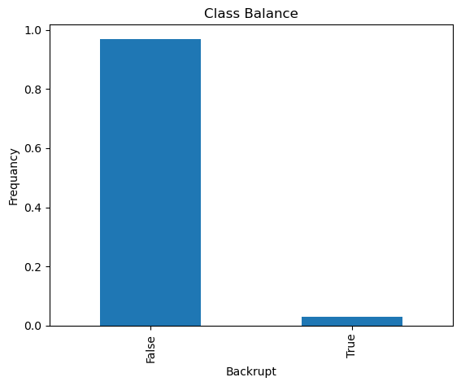

```python
# Plot class balance
df['bankrupt'].value_counts(normalize=True).plot(
    kind=("bar") ,xlabel=("Backrupt"),ylabel=("Frequancy"),title=("Class Balance")
);
# Don't delete the code below 👇
plt.savefig("images/5-5-7.png", dpi=150)
```

```python
with open("images/5-5-7.png", "rb") as file:
    wqet_grader.grade("Project 5 Assessment", "Task 5.5.7", file)
```

Excellent work.

Score: 1

## Split

**Task 5.5.8:** Create your feature matrix `X` and target vector `y`. Your target is `"bankrupt"`.

```python
target = 'bankrupt'
X = df.drop(columns = target)
y = df[target]
print("X shape:", X.shape)
print("y shape:", y.shape)
```

```
X shape: (6137, 95)
y shape: (6137,)
```

```python
wqet_grader.grade("Project 5 Assessment", "Task 5.5.8a", X)
```

Excellent work.

Score: 1

```python
wqet_grader.grade("Project 5 Assessment", "Task 5.5.8b", y)
```

Yes! Your hard work is paying off.

Score: 1

**Task 5.5.9:** Divide your dataset into training and test sets using a randomized split. Your test set should be 20% of your data. Be sure to set `random_state` to `42`.

```python
X_train, X_test, y_train, y_test = train_test_split(X,y,test_size=0.2,random_state=42)
print("X_train shape:", X_train.shape)
print("y_train shape:", y_train.shape)
print("X_test shape:", X_test.shape)
print("y_test shape:", y_test.shape)
```

```
X_train shape: (4909, 95)
y_train shape: (4909,)
X_test shape: (1228, 95)
y_test shape: (1228,)
```

```python
wqet_grader.grade("Project 5 Assessment", "Task 5.5.9", list(X_train.shape))
```

Yes! Your hard work is paying off.

Score: 1

## Resample

**Task 5.5.10:** Create a new feature matrix `X_train_over` and target vector `y_train_over` by performing random over-sampling on the training data. Be sure to set the `random_state` to `42`.

```python
over_sampler = RandomOverSampler(random_state=42)
X_train_over, y_train_over = over_sampler.fit_resample(X_train,y_train)
print("X_train_over shape:", X_train_over.shape)
X_train_over.head()
```

```
X_train_over shape: (9512, 95)
```

|  | feat_1 | feat_2 | feat_3 | feat_4 | feat_5 | feat_6 | feat_7 | feat_8 | feat_9 | feat_10 | ... | feat_86 | feat_87 | feat_88 | feat_89 | feat_90 | feat_91 | feat_92 | feat_93 | feat_94 | feat_95 |
| --- | --- | --- | --- | --- | --- | --- | --- | --- | --- | --- | --- | --- | --- | --- | --- | --- | --- | --- | --- | --- | --- |
| 0 | 0.535855 | 0.599160 | 0.594411 | 0.627099 | 0.627099 | 0.999220 | 0.797686 | 0.809591 | 0.303518 | 0.781865 | ... | 0.834091 | 0.022025 | 0.624364 | 0.627101 | 0.841977 | 0.275384 | 0.026791 | 0.565158 | 1 | 0.147943 |
| 1 | 0.554136 | 0.612734 | 0.595000 | 0.607388 | 0.607388 | 0.999120 | 0.797614 | 0.809483 | 0.303600 | 0.781754 | ... | 0.840293 | 0.002407 | 0.624548 | 0.607385 | 0.842645 | 0.276532 | 0.026791 | 0.565158 | 1 | 0.062544 |
| 2 | 0.549554 | 0.603467 | 0.599122 | 0.620166 | 0.620166 | 0.999119 | 0.797569 | 0.809470 | 0.303524 | 0.781740 | ... | 0.840403 | 0.000840 | 0.624010 | 0.620163 | 0.842873 | 0.277249 | 0.026800 | 0.565200 | 1 | 0.047929 |
| 3 | 0.543801 | 0.603249 | 0.606992 | 0.622515 | 0.622515 | 0.999259 | 0.797728 | 0.809649 | 0.303510 | 0.781930 | ... | 0.831514 | 0.006176 | 0.626775 | 0.622513 | 0.842989 | 0.280013 | 0.026839 | 0.565375 | 1 | 0.028386 |
| 4 | 0.498659 | 0.562364 | 0.546978 | 0.603670 | 0.603670 | 0.998904 | 0.797584 | 0.809459 | 0.304000 | 0.781713 | ... | 0.811988 | 0.004256 | 0.623674 | 0.603669 | 0.841105 | 0.277628 | 0.026897 | 0.565618 | 1 | 0.043080 |

5 rows × 95 columns

```python
wqet_grader.grade("Project 5 Assessment", "Task 5.5.10", list(X_train_over.shape))
```

You got it. Dance party time! 🕺💃🕺💃

Score: 1